# Superstore Orders, Sales and Profit Analysis

## Overall Profit by Category

```python
profitbycategory=data.groupby("Category")["Profit"].sum().reset_index()
profitbycategory
```

|  | Category | Profit |
| --- | --- | --- |
| 0 | Furniture | 18451.2728 |
| 1 | Office Supplies | 122490.8008 |
| 2 | Technology | 145454.9481 |

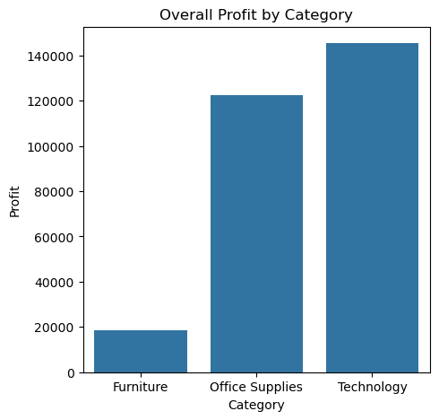

```python
plt.figure(figsize=(5,5))
sns.barplot(profitbycategory,x="Category",y="Profit")
plt.title("Overall Profit by Category")
plt.show()
```

## Yearly Profit Overview by category

```python
yearlyprofitbycategory=data.groupby(["year","Category"])["Profit"].sum().reset_index().round(2)
yearlyprofitbycategory
```

|  | year | Category | Profit |
| --- | --- | --- | --- |
| 0 | 2014 | Furniture | 5457.73 |
| 1 | 2014 | Office Supplies | 22593.42 |
| 2 | 2014 | Technology | 21492.83 |
| 3 | 2015 | Furniture | 3015.20 |
| 4 | 2015 | Office Supplies | 25099.53 |
| 5 | 2015 | Technology | 33503.87 |
| 6 | 2016 | Furniture | 6959.95 |
| 7 | 2016 | Office Supplies | 35061.23 |
| 8 | 2016 | Technology | 39773.99 |
| 9 | 2017 | Furniture | 3018.39 |
| 10 | 2017 | Office Supplies | 39736.62 |
| 11 | 2017 | Technology | 50684.26 |

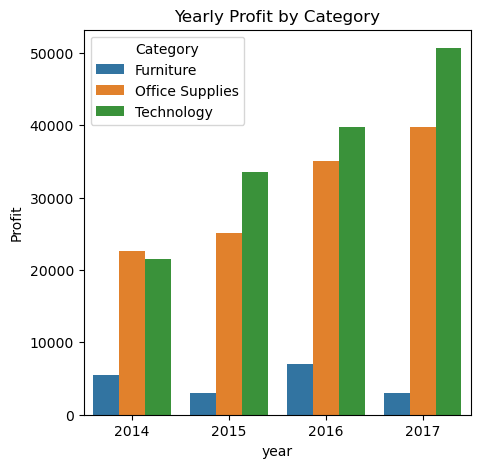

```python
plt.figure(figsize=(5,5))
sns.barplot(yearlyprofitbycategory,x="year",y="Profit",hue="Category")
plt.title("Yearly Profit by Category")
plt.show()
```

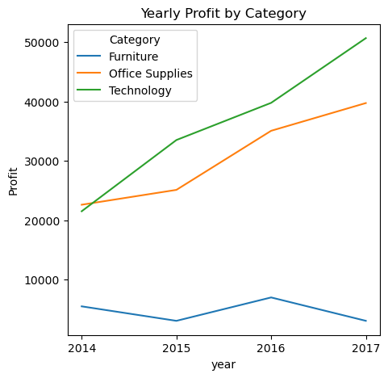

```python
plt.figure(figsize=(5,5))
sns.lineplot(yearlyprofitbycategory,x="year",y="Profit",hue="Category")
plt.xticks(np.arange(yearlyprofitbycategory['year'].min(), yearlyprofitbycategory['year'].max() + 1, 1))
#np.arange(start, stop, step) generates an array of integer values from the min year to max year with step 1.
#plt.xticks()explicitly sets the x-axis ticks to those integers.
plt.title("Yearly Profit by Category")
plt.show()
```

## Monthly Profit Overview by Category

```python
monthsof2014profitbycategory=dataof2014.groupby(["month","Category"])["Profit"].sum().reset_index()
monthsof2014profitbycategory
# dataof2014 its defined in sales overview
```

|  | month | Category | Profit |
| --- | --- | --- | --- |
| 0 | 1 | Furniture | 805.4665 |
| 1 | 1 | Office Supplies | 788.9506 |
| 2 | 1 | Technology | 855.7736 |
| 3 | 2 | Furniture | 120.6917 |
| 4 | 2 | Office Supplies | 176.0910 |
| 5 | 2 | Technology | 565.5257 |
| 6 | 3 | Furniture | -1128.6550 |
| 7 | 3 | Office Supplies | 1270.4133 |
| 8 | 3 | Technology | 356.9716 |
| 9 | 4 | Furniture | 554.3801 |
| 10 | 4 | Office Supplies | 1000.2086 |
| 11 | 4 | Technology | 1934.2465 |
| 12 | 5 | Furniture | -349.8776 |
| 13 | 5 | Office Supplies | 1747.2044 |
| 14 | 5 | Technology | 1341.3828 |
| 15 | 6 | Furniture | 596.3153 |
| 16 | 6 | Office Supplies | 3031.4326 |
| 17 | 6 | Technology | 1348.7765 |
| 18 | 7 | Furniture | 374.2467 |
| 19 | 7 | Office Supplies | -2482.0172 |
| 20 | 7 | Technology | 1266.2879 |
| 21 | 8 | Furniture | 663.4717 |
| 22 | 8 | Office Supplies | 2767.6007 |
| 23 | 8 | Technology | 1887.0326 |
| 24 | 9 | Furniture | 1858.5976 |
| 25 | 9 | Office Supplies | 6699.5402 |
| 26 | 9 | Technology | -230.0384 |
| 27 | 10 | Furniture | 249.1645 |
| 28 | 10 | Office Supplies | 1117.6406 |
| 29 | 10 | Technology | 2081.4522 |
| 30 | 11 | Furniture | -297.8958 |
| 31 | 11 | Office Supplies | 4411.9560 |
| 32 | 11 | Technology | 5178.0667 |
| 33 | 12 | Furniture | 2011.8198 |
| 34 | 12 | Office Supplies | 2064.3953 |
| 35 | 12 | Technology | 4907.3548 |

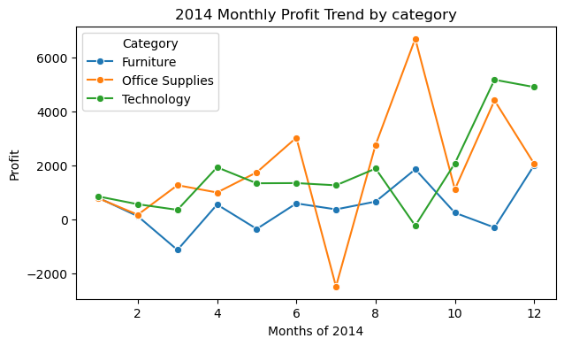

```python
plt.figure(figsize=(7,4))
sns.lineplot(monthsof2014profitbycategory,x="month",y="Profit",marker="o",hue="Category")
plt.xlabel("Months of 2014")
plt.title("2014 Monthly Profit Trend by category" )
plt.show()
```

```python
monthsof2015profitcategory=dataof2015.groupby(["month","Category"])["Profit"].sum().reset_index()
monthsof2015profitcategory
```

|  | month | Category | Profit |
| --- | --- | --- | --- |
| 0 | 1 | Furniture | -3014.2000 |
| 1 | 1 | Office Supplies | 589.8969 |
| 2 | 1 | Technology | -856.7039 |
| 3 | 2 | Furniture | 394.8948 |
| 4 | 2 | Office Supplies | 1814.1018 |
| 5 | 2 | Technology | 604.8542 |
| 6 | 3 | Furniture | 1455.0573 |
| 7 | 3 | Office Supplies | 5407.8482 |
| 8 | 3 | Technology | 2869.1923 |
| 9 | 4 | Furniture | 338.6502 |
| 10 | 4 | Office Supplies | 1477.3596 |
| 11 | 4 | Technology | 2371.4864 |
| 12 | 5 | Furniture | 900.5847 |
| 13 | 5 | Office Supplies | 1731.6139 |
| 14 | 5 | Technology | 2035.6704 |
| 15 | 6 | Furniture | -412.6597 |
| 16 | 6 | Office Supplies | 2195.3864 |
| 17 | 6 | Technology | 1552.8305 |
| 18 | 7 | Furniture | -325.0938 |
| 19 | 7 | Office Supplies | 1113.7829 |
| 20 | 7 | Technology | 2499.9592 |
| 21 | 8 | Furniture | -487.4709 |
| 22 | 8 | Office Supplies | 2208.7531 |
| 23 | 8 | Technology | 3634.5262 |
| 24 | 9 | Furniture | 1350.1185 |
| 25 | 9 | Office Supplies | 2037.8837 |
| 26 | 9 | Technology | 4821.1605 |
| 27 | 10 | Furniture | -605.5163 |
| 28 | 10 | Office Supplies | 1090.9375 |
| 29 | 10 | Technology | 2331.9448 |
| 30 | 11 | Furniture | 2992.0240 |
| 31 | 11 | Office Supplies | 2800.0289 |
| 32 | 11 | Technology | 6682.7355 |
| 33 | 12 | Furniture | 428.8141 |
| 34 | 12 | Office Supplies | 2631.9409 |
| 35 | 12 | Technology | 4956.2109 |

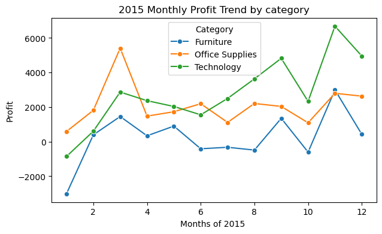

```python
plt.figure(figsize=(7,4))
sns.lineplot(monthsof2015profitcategory,x="month",y="Profit",marker="o",hue="Category")
plt.xlabel("Months of 2015 ")
plt.title("2015 Monthly Profit Trend by category" )
plt.show()
```

```python
monthsof2016profitbycategory=dataof2016.groupby(["month","Category"])["Profit"].sum().reset_index()
monthsof2016profitbycategory
```

|  | month | Category | Profit |
| --- | --- | --- | --- |
| 0 | 1 | Furniture | 303.9607 |
| 1 | 1 | Office Supplies | 1604.4712 |
| 2 | 1 | Technology | 916.3914 |
| 3 | 2 | Furniture | 377.0352 |
| 4 | 2 | Office Supplies | 1330.0009 |
| 5 | 2 | Technology | 3297.5434 |
| 6 | 3 | Furniture | -555.2680 |
| 7 | 3 | Office Supplies | 1061.4056 |
| 8 | 3 | Technology | 3105.8304 |
| 9 | 4 | Furniture | 364.8334 |
| 10 | 4 | Office Supplies | -1100.4821 |
| 11 | 4 | Technology | 3713.4636 |
| 12 | 5 | Furniture | 1824.4739 |
| 13 | 5 | Office Supplies | 2397.5024 |
| 14 | 5 | Technology | 4440.1701 |
| 15 | 6 | Furniture | -106.2665 |
| 16 | 6 | Office Supplies | 2467.4894 |
| 17 | 6 | Technology | 2389.1552 |
| 18 | 7 | Furniture | 1038.9073 |
| 19 | 7 | Office Supplies | 1123.9602 |
| 20 | 7 | Technology | 2270.0104 |
| 21 | 8 | Furniture | -494.1457 |
| 22 | 8 | Office Supplies | 1629.1913 |
| 23 | 8 | Technology | 927.0237 |
| 24 | 9 | Furniture | 702.6025 |
| 25 | 9 | Office Supplies | 3714.0417 |
| 26 | 9 | Technology | 4912.0134 |
| 27 | 10 | Furniture | -144.6600 |
| 28 | 10 | Office Supplies | 4680.0550 |
| 29 | 10 | Technology | 11707.7475 |
| 30 | 11 | Furniture | 819.8088 |
| 31 | 11 | Office Supplies | 4686.9250 |
| 32 | 11 | Technology | -1495.3263 |
| 33 | 12 | Furniture | 2828.6715 |
| 34 | 12 | Office Supplies | 11466.6686 |
| 35 | 12 | Technology | 3589.9692 |

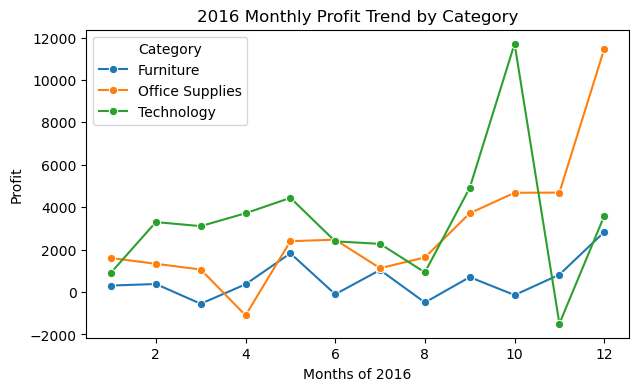

```python
plt.figure(figsize=(7,4))
sns.lineplot(monthsof2016profitbycategory,x="month",y="Profit",marker="o",hue="Category")
plt.xlabel("Months of 2016")
plt.title("2016 Monthly Profit Trend by Category" )
plt.show()
```

```python
monthsof2017profitbycategory=dataof2017.groupby(["month","Category"])["Profit"].sum().reset_index()
monthsof2017profitbycategory
```

|  | month | Category | Profit |
| --- | --- | --- | --- |
| 0 | 1 | Furniture | -39.4402 |
| 1 | 1 | Office Supplies | 3260.4467 |
| 2 | 1 | Technology | 3919.4326 |
| 3 | 2 | Furniture | -199.0421 |
| 4 | 2 | Office Supplies | 953.8253 |
| 5 | 2 | Technology | 859.0888 |
| 6 | 3 | Furniture | 1000.8532 |
| 7 | 3 | Office Supplies | 2715.9624 |
| 8 | 3 | Technology | 11035.0759 |
| 9 | 4 | Furniture | 202.4624 |
| 10 | 4 | Office Supplies | 3370.6015 |
| 11 | 4 | Technology | -2639.7739 |
| 12 | 5 | Furniture | -72.8829 |
| 13 | 5 | Office Supplies | 3153.7260 |
| 14 | 5 | Technology | 3261.7397 |
| 15 | 6 | Furniture | 904.9956 |
| 16 | 6 | Office Supplies | 3378.9821 |
| 17 | 6 | Technology | 3939.3580 |
| 18 | 7 | Furniture | 324.6244 |
| 19 | 7 | Office Supplies | 2563.2845 |
| 20 | 7 | Technology | 4064.7123 |
| 21 | 8 | Furniture | 322.2390 |
| 22 | 8 | Office Supplies | 6067.8582 |
| 23 | 8 | Technology | 2650.8585 |
| 24 | 9 | Furniture | 1548.6837 |
| 25 | 9 | Office Supplies | 4847.7438 |
| 26 | 9 | Technology | 4595.1281 |
| 27 | 10 | Furniture | -2526.9203 |
| 28 | 10 | Office Supplies | 4040.7751 |
| 29 | 10 | Technology | 7761.4207 |
| 30 | 11 | Furniture | 406.0637 |
| 31 | 11 | Office Supplies | 3609.1029 |
| 32 | 11 | Technology | 5674.9371 |
| 33 | 12 | Furniture | 1146.7548 |
| 34 | 12 | Office Supplies | 1774.3132 |
| 35 | 12 | Technology | 5562.2788 |

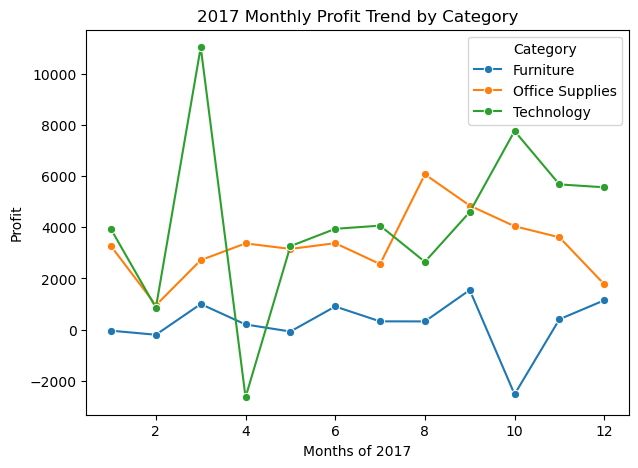

```python
plt.figure(figsize=(7,5))
sns.lineplot(monthsof2017profitbycategory,x="month",y="Profit",marker="o",hue="Category")
plt.xlabel("Months of 2017")
plt.title("2017 Monthly Profit Trend by Category" )
plt.show()
```

## Profit Overview by Sub-category

```python
profitbysubcategory=data.groupby(["Category","Sub-Category"])["Profit"].sum().reset_index().sort_values(by=["Category","Profit"], ascending=True)
profitbysubcategory
```

|  | Category | Sub-Category | Profit |
| --- | --- | --- | --- |
| 3 | Furniture | Tables | -17725.4811 |
| 0 | Furniture | Bookcases | -3472.5560 |
| 2 | Furniture | Furnishings | 13059.1436 |
| 1 | Furniture | Chairs | 26590.1663 |
| 12 | Office Supplies | Supplies | -1189.0995 |
| 8 | Office Supplies | Fasteners | 949.5182 |
| 9 | Office Supplies | Labels | 5546.2540 |
| 5 | Office Supplies | Art | 6527.7870 |
| 7 | Office Supplies | Envelopes | 6964.1767 |
| 4 | Office Supplies | Appliances | 18138.0054 |
| 11 | Office Supplies | Storage | 21278.8264 |
| 6 | Office Supplies | Binders | 30221.7633 |
| 10 | Office Supplies | Paper | 34053.5693 |
| 15 | Technology | Machines | 3384.7569 |
| 13 | Technology | Accessories | 41936.6357 |
| 16 | Technology | Phones | 44515.7306 |
| 14 | Technology | Copiers | 55617.8249 |

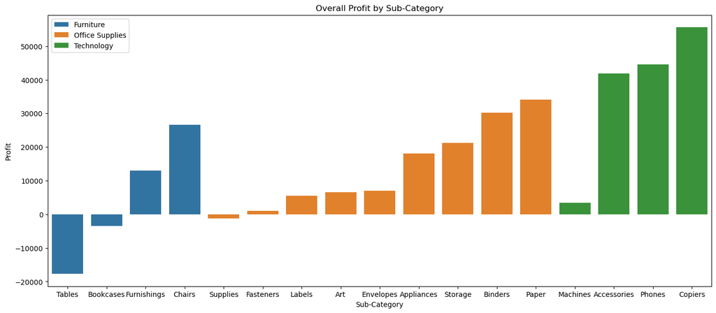

```python
plt.figure(figsize=(17,7))
sns.barplot(profitbysubcategory,x="Sub-Category",y="Profit",hue="Category")
plt.title("Overall Profit by Sub-Category")
plt.legend(loc=2)
plt.show()
```

## Profit Overview of Subcategory by Years

```python
profitbysubcategory2014=dataof2014.groupby(["Category","Sub-Category"])["Profit"].sum().reset_index().sort_values(by=["Category","Profit"], ascending=True)
profitbysubcategory2014
```

|  | Category | Sub-Category | Profit |
| --- | --- | --- | --- |
| 3 | Furniture | Tables | -3124.0427 |
| 0 | Furniture | Bookcases | -346.1707 |
| 2 | Furniture | Furnishings | 1972.8919 |
| 1 | Furniture | Chairs | 6955.0470 |
| 8 | Office Supplies | Fasteners | 178.5583 |
| 12 | Office Supplies | Supplies | 490.0556 |
| 9 | Office Supplies | Labels | 1286.0042 |
| 5 | Office Supplies | Art | 1406.8031 |
| 7 | Office Supplies | Envelopes | 1495.4788 |
| 4 | Office Supplies | Appliances | 2459.4999 |
| 11 | Office Supplies | Storage | 4166.2788 |
| 6 | Office Supplies | Binders | 4739.7160 |
| 10 | Office Supplies | Paper | 6371.0214 |
| 15 | Technology | Machines | 369.1689 |
| 14 | Technology | Copiers | 2912.9433 |
| 13 | Technology | Accessories | 6402.7150 |
| 16 | Technology | Phones | 11808.0053 |

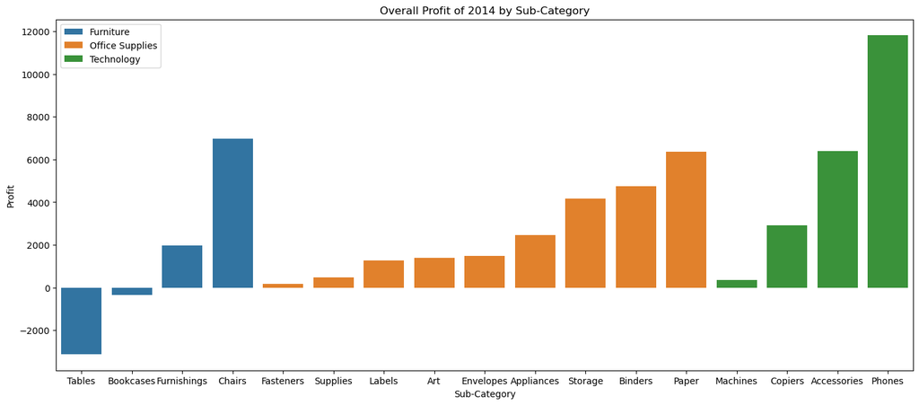

```python
plt.figure(figsize=(17,7))
sns.barplot(profitbysubcategory2014,x="Sub-Category",y="Profit",hue="Category")
plt.title("Overall Profit of 2014 by Sub-Category")
plt.legend(loc=2)
plt.show()
```

```python
profitbysubcategory2015=dataof2015.groupby(["Category","Sub-Category"])["Profit"].sum().reset_index().sort_values(by=["Category","Profit"], ascending=True)
profitbysubcategory2015
```

|  | Category | Sub-Category | Profit |
| --- | --- | --- | --- |
| 3 | Furniture | Tables | -3509.8019 |
| 0 | Furniture | Bookcases | -2755.2302 |
| 2 | Furniture | Furnishings | 3051.8189 |
| 1 | Furniture | Chairs | 6228.4161 |
| 12 | Office Supplies | Supplies | -24.8784 |
| 8 | Office Supplies | Fasteners | 171.9376 |
| 9 | Office Supplies | Labels | 1323.0286 |
| 5 | Office Supplies | Art | 1485.0582 |
| 7 | Office Supplies | Envelopes | 1960.1906 |
| 4 | Office Supplies | Appliances | 2511.8957 |
| 11 | Office Supplies | Storage | 3505.4601 |
| 10 | Office Supplies | Paper | 6570.1700 |
| 6 | Office Supplies | Binders | 7596.6714 |
| 15 | Technology | Machines | 2977.4856 |
| 14 | Technology | Copiers | 9930.2988 |
| 13 | Technology | Accessories | 10197.2752 |
| 16 | Technology | Phones | 10398.8074 |

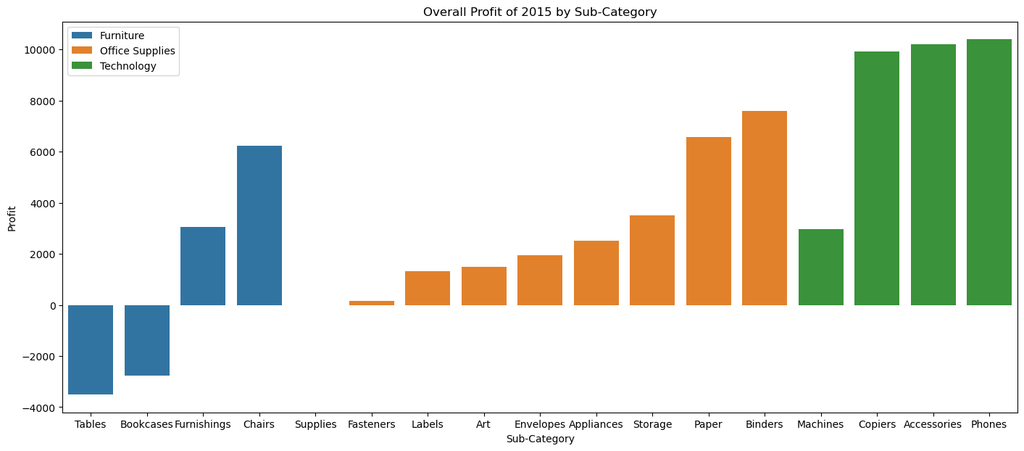

```python
plt.figure(figsize=(17,7))
sns.barplot(profitbysubcategory2015,x="Sub-Category",y="Profit",hue="Category")
plt.title("Overall Profit of 2015 by Sub-Category")
plt.legend(loc=2)
plt.show()
```

```python
profitbysubcategory2016=dataof2016.groupby(["Category","Sub-Category"])["Profit"].sum().reset_index().sort_values(by=["Category","Profit"], ascending=True)
profitbysubcategory2016
```

|  | Category | Sub-Category | Profit |
| --- | --- | --- | --- |
| 3 | Furniture | Tables | -2950.9418 |
| 0 | Furniture | Bookcases | 212.4710 |
| 2 | Furniture | Furnishings | 3935.2700 |
| 1 | Furniture | Chairs | 5763.1539 |
| 12 | Office Supplies | Supplies | -698.9639 |
| 8 | Office Supplies | Fasteners | 294.0734 |
| 9 | Office Supplies | Labels | 1192.6119 |
| 5 | Office Supplies | Art | 1413.9626 |
| 7 | Office Supplies | Envelopes | 2066.7483 |
| 4 | Office Supplies | Appliances | 5301.3415 |
| 11 | Office Supplies | Storage | 6204.2868 |
| 10 | Office Supplies | Paper | 9071.5345 |
| 6 | Office Supplies | Binders | 10215.6341 |
| 15 | Technology | Machines | 2907.3180 |
| 16 | Technology | Phones | 9459.5929 |
| 13 | Technology | Accessories | 9664.2885 |
| 14 | Technology | Copiers | 17742.7926 |

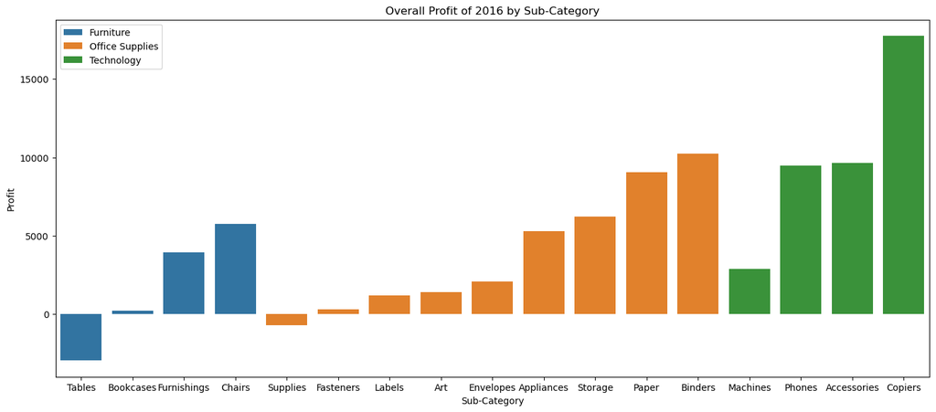

```python
plt.figure(figsize=(17,7))
sns.barplot(profitbysubcategory2016,x="Sub-Category",y="Profit",hue="Category")
plt.title("Overall Profit of 2016 by Sub-Category")
plt.legend(loc=2)
plt.show()
```

```python
profitbysubcategory2017=dataof2017.groupby(["Category","Sub-Category"])["Profit"].sum().reset_index().sort_values(by=["Category","Profit"], ascending=True)
profitbysubcategory2017
```

|  | Category | Sub-Category | Profit |
| --- | --- | --- | --- |
| 3 | Furniture | Tables | -8140.6947 |
| 0 | Furniture | Bookcases | -583.6261 |
| 2 | Furniture | Furnishings | 4099.1628 |
| 1 | Furniture | Chairs | 7643.5493 |
| 12 | Office Supplies | Supplies | -955.3128 |
| 8 | Office Supplies | Fasteners | 304.9489 |
| 7 | Office Supplies | Envelopes | 1441.7590 |
| 9 | Office Supplies | Labels | 1744.6093 |
| 5 | Office Supplies | Art | 2221.9631 |
| 11 | Office Supplies | Storage | 7402.8007 |
| 6 | Office Supplies | Binders | 7669.7418 |
| 4 | Office Supplies | Appliances | 7865.2683 |
| 10 | Office Supplies | Paper | 12040.8434 |
| 15 | Technology | Machines | -2869.2156 |
| 16 | Technology | Phones | 12849.3250 |
| 13 | Technology | Accessories | 15672.3570 |
| 14 | Technology | Copiers | 25031.7902 |

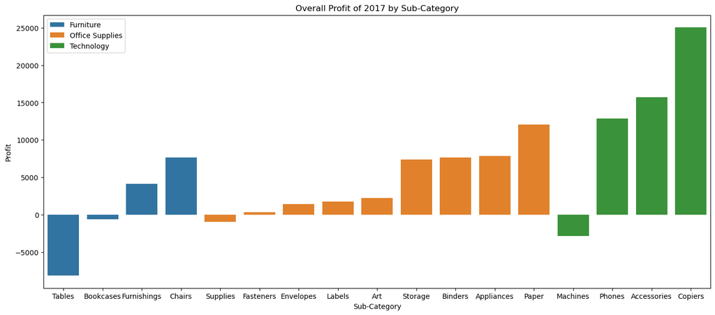

```python
plt.figure(figsize=(17,7))
sns.barplot(profitbysubcategory2017,x="Sub-Category",y="Profit",hue="Category")
plt.title("Overall Profit of 2017 by Sub-Category")
plt.legend(loc=2)
plt.show()
```

# State Overview

## Top 10 State by Sales

```python
statebysales=data.groupby("State")[["Sales","Profit"]].sum().reset_index().sort_values(by="Sales",ascending=False)[:10]
statebysales
```

|  | State | Sales | Profit |
| --- | --- | --- | --- |
| 3 | California | 457687.6315 | 76381.3871 |
| 30 | New York | 310876.2710 | 74038.5486 |
| 41 | Texas | 170188.0458 | -25729.3563 |
| 45 | Washington | 138641.2700 | 33402.6517 |
| 36 | Pennsylvania | 116511.9140 | -15559.9603 |
| 8 | Florida | 89473.7080 | -3399.3017 |
| 11 | Illinois | 80166.1010 | -12607.8870 |
| 33 | Ohio | 78258.1360 | -16971.3766 |
| 20 | Michigan | 76269.6140 | 24463.1876 |
| 44 | Virginia | 70636.7200 | 18597.9504 |

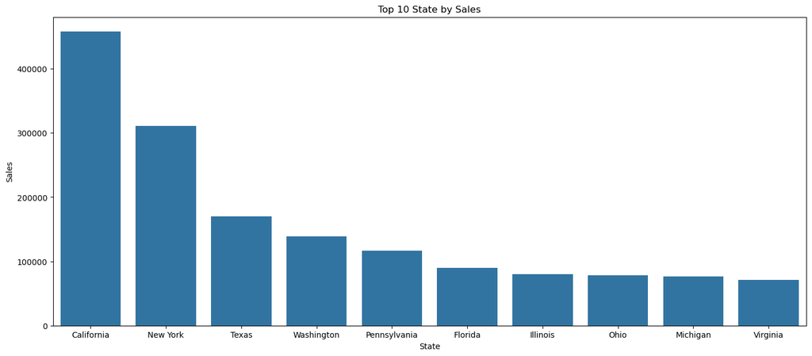

```python
plt.figure(figsize=(17,7))
sns.barplot(statebysales,x="State",y="Sales")
plt.title("Top 10 State by Sales")
plt.show()
```

## Top 10 State by Profit

```python
statebyprofit=data.groupby("State")[["Sales","Profit"]].sum().reset_index().sort_values(by="Profit",ascending=False)[:10]
statebyprofit
```

|  | State | Sales | Profit |
| --- | --- | --- | --- |
| 3 | California | 457687.6315 | 76381.3871 |
| 30 | New York | 310876.2710 | 74038.5486 |
| 45 | Washington | 138641.2700 | 33402.6517 |
| 20 | Michigan | 76269.6140 | 24463.1876 |
| 44 | Virginia | 70636.7200 | 18597.9504 |
| 12 | Indiana | 53555.3600 | 18382.9363 |
| 9 | Georgia | 49095.8400 | 16250.0433 |
| 15 | Kentucky | 36591.7500 | 11199.6966 |
| 21 | Minnesota | 29863.1500 | 10823.1874 |
| 6 | Delaware | 27451.0690 | 9977.3748 |

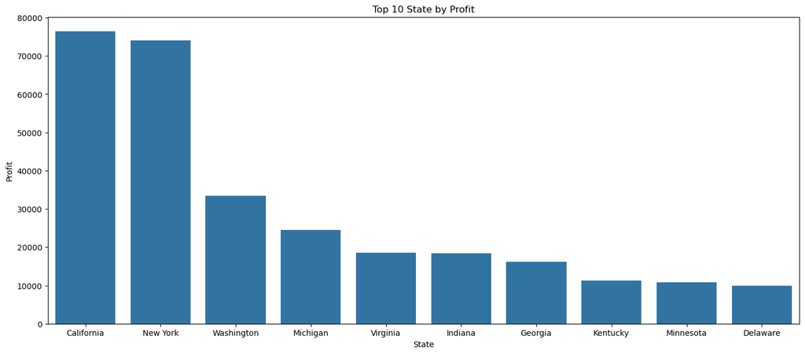

```python
plt.figure(figsize=(17,7))
sns.barplot(statebyprofit,x="State",y="Profit")
plt.title("Top 10 State by Profit")
plt.show()
```

# City Overview

## Top 10 City by Sales

```python
salesbycity=data.groupby("City")[["Sales","Profit"]].sum().reset_index().sort_values(by="Sales",ascending=False)[:10]
salesbycity["City"]
```

```
329    New York City
266      Los Angeles
452          Seattle
438    San Francisco
374     Philadelphia
207          Houston
80           Chicago
437        San Diego
216     Jacksonville
464      Springfield
Name: City, dtype: object
```

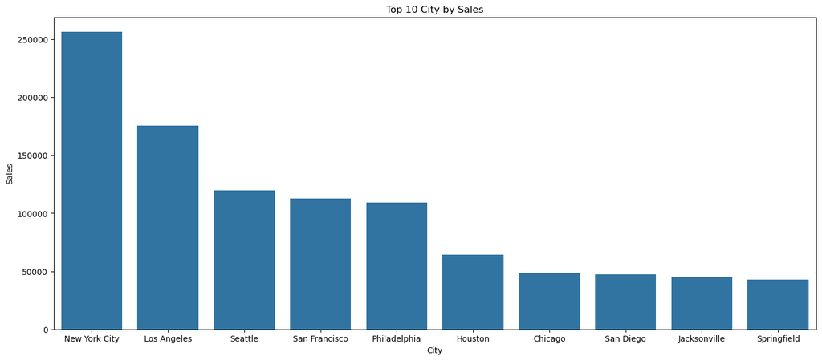

```python
plt.figure(figsize=(17,7))
sns.barplot(salesbycity,x="City",y="Sales")
plt.title("Top 10 City by Sales")
plt.show()
```

## Top 10 City by Profit

```python
profitbycity=data.groupby("City")[["Sales","Profit"]].sum().reset_index().sort_values(by="Profit",ascending=False)[:10]
profitbycity
```

|  | City | Sales | Profit |
| --- | --- | --- | --- |
| 329 | New York City | 256368.161 | 62036.9837 |
| 266 | Los Angeles | 175851.341 | 30440.7579 |
| 452 | Seattle | 119540.742 | 29156.0967 |
| 438 | San Francisco | 112669.092 | 17507.3854 |
| 123 | Detroit | 42446.944 | 13181.7908 |
| 233 | Lafayette | 25036.200 | 10018.3876 |
| 215 | Jackson | 24963.858 | 7581.6828 |
| 21 | Atlanta | 17197.840 | 6993.6629 |
| 300 | Minneapolis | 16870.540 | 6824.5846 |
| 437 | San Diego | 47521.029 | 6377.1960 |

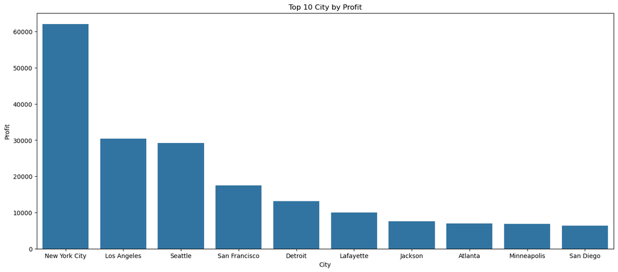

```python
plt.figure(figsize=(17,7))
sns.barplot(profitbycity,x="City",y="Profit")
plt.title("Top 10 City by Profit")
plt.show()
```

# Insights

## Sales Insights

#### 1.Sales Seasonality:

- January and February are consistently the lowest-performing months in terms of sales.
- September and November emerge as peak sales months, indicating strong seasonal or promotional demand.
- Quarter 4 (October to December) contributes the highest overall sales, making it crucial for revenue planning.

#### 2. Segment-Wise Performance:

- The Consumer segment generates the majority of sales, showcasing strong B2C performance. This is followed by the Corporate and Home Office segments, which also show consistent contributions.

#### 3. Category-Wise Sales:

- Technology is the top-selling category, driven by high demand for electronics. Furniture ranks second, followed closely by Office Supplies.

#### 4. Sub-Categories by Sales:

- Chairs (Furniture), Phones (Technology), and Storage (Office Supplies) are the leading sub-categories in total sales value. These sub-categories should be prioritized in inventory planning and promotional strategies.

## Profit Insights

The store has demonstrated consistent yearly growth in profit, indicating a healthy business trajectory.

#### 1. Category-Wise Profit

- Technology has highest profit followed by Office Supplies and Furniture. When evaluated on Sales to Profit Ratio:
- Office Supplies show the highest efficiency with a 15% profit margin. Technology follows with 13%, and Furniture trails with just 4%.

#### 2. Sub-Category Performance

- Technology Top-performing subcateogry: Copiers followed by Phones, and Accessories.
- Office Supplies Top-performing subcateogry: Paper followed by Binders and Storage.
- Furniture Top-performing subcateogry : Chairs and Furnishings are the most profitable.

#### 3. Loss-Making Sub-Categories

- Tables and Bookcases (under Furniture), and Supplies (Office Supplies) often negative profits despite high sales volumes.

## State-wise Summary

- California has the highest sales, followed by New York, Texas, Washington, Pennsylvania, Florida, Illinois, Ohio, Michigan, and Virginia.
- Even Though Texas, Pennsylvania, Florida, Illinois, and Ohio have high sales but are losing money.

## City-wise Summary

- New York City has the best sales and profits followed by Los Angeles, Seattle,

San Francisco, Philadelphia, Houston, Chicago, San Diego, Jacksonville, and Springfield.